# Introductory Vignette for rzeit

Jana Blahak & Jan Dix

2016-05-27

This is an introductory vignette to the [`rzeit`](https://github.com/tollpatsch/rzeit) package. The package connects to the [Content API](http://developer.zeit.de/index/) and gives access to articles and corresponding metadata from the DIE ZEIT archive dating back to 1946 and from [ZEIT Online](http://www.zeit.de/). DIE ZEIT is the most widely read German weekly newspaper. The API can be used for free for non-commercial use cases. For the terms of use see http://developer.zeit.de/licence (German only at the moment).

In short the package allows you to:

- conduct an unfiltered search for articles,
- use a variety of parameters to refine query fields, e.g. to specify content and time, and
- easily inspect meta as well as article data.

The package is made publicly available at [GitHub](https://github.com/tollpatsch/rzeit). In this vignette we demonstrate basic features of the package. In a second vignette, we will dig deeper into the matter and show how the package can be used to construct networks of popular German politicians.

## Setup

Currently, the package is only available on GitHub. Using the `devtools` package, you can easily install it:

```r
devtools::install_github("tollpatsch/rzeit")
```

```r
library(rzeit)
```

## Basic functions

To be able to work with the API, we have to fetch an API key first. There is no sophisticated authentication process involved here–just go to the [developer page](http://developer.zeit.de/quickstart/) and sign up by providing your name and a valid email address.

With `zeitSetApiKey`, we provide a comfortable function that stores the key in the `R` environment You only have to do this once; the next time `R` is launched this key is automatically available and fetched by the package’s functions:

```r
zeitSetApiKey(apiKey = "set_your_api_key_here")
```

Next, we can start tapping the API. `zeitGet` represents the core function of the package. Again, because the API Key is stored in the environment, we do not have to pass the key explicitly (but still could do so using the `api` argument). As an example, we collect articles that include “Merkel” in the article body, headline or byline:

```r
merkel <- zeitGet(q = "Merkel",
                   limit = 100,
                   dateBegin = "2015-01-01",
                   dateEnd = "2015-12-31")
```

Note that for the ease of exposition, we limited the number of collected results to 100 here using the `limit` argument. The maximum limit per call is 1000. Further, we restricted the search to articles that were published in a time period of about one year.

The `results` object is of class `list` and provides information about the articles found as well as the number of hits for a given period. To extract information about the latter, we can draw on the `zeitFrequencies` function, which takes the `results` object as main argument and returns a data frame that includes a continous list of dates in choosen sequences and the related frequencies:

```r
merkel_freq <- zeitFrequencies(ls = merkel,
                               sort = "day")
head(merkel_freq)
```

```
##         date        day dayCount freq freqRel
## 1 2015-12-01 2015-12-01        1    1      11
## 2 2015-12-02 2015-12-02        2    4      44
## 3 2015-12-03 2015-12-03        3    5      56
## 4 2015-12-04 2015-12-04        4    5      56
## 5 2015-12-05 2015-12-05        5    1      11
## 6 2015-12-06 2015-12-06        6    2      22
```

Apart from these meta data, we can also process substantive article information. The function `zeitToDf` converts the list returned from `zeitGet` into a data frame. Articles can optionally be sorted by any meta data variable:

```r
merkel_articles <- zeitToDf(ls = merkel,
                            sort = "release_date")
```

```
## release_datenot found in data set. Data might be sorted by:datetitlesubtitlehrefuriuuidsupertitlesnippetteaser_textteaser_title
```

```r
names(merkel_articles)
```

```
##  [1] "date"         "title"        "subtitle"     "href"
##  [5] "uri"          "uuid"         "supertitle"   "snippet"
##  [9] "teaser_text"  "teaser_title"
```

Finally, we offer the function `zeitPlot` that offers a first inspection of the collected time series. It plots date versus frequencies based on the frequency data frame returned by `zeitFrequencies`:

```r
zeitPlot(df = merkel_freq)
```

[output not shown]

## Detailed example

So much for the package’s basic functionality. In the following, we marginally modify our running example to demonstrate additional features of the `zeitGet` function.

### Perform queries

Now we search for multiple strings, i.e. articles containing “Bundeskanzlerin” or “Angela Merkel”, in her first legislative period as the German chancellor. Furthermore, we set `limit = "all"` to get a comlete list of articles:

```r
merkel_1 <- zeitGet(q = c("Bundeskanzlerin", "Angela Merkel"),
                     limit = "all",
                     dateBegin = "2005-11-22",
                     dateEnd = "2009-10-27")
```

For the second run we add a “+” to the (second) search term, to force a search for articles containing both, “Bundeskanzlerin” *and* “Angela Merkel”:

```r
merkel_2 <- zeitGet(q = c("Bundeskanzlerin", "+Angela Merkel"),
                     limit = "all",
                     dateBegin = "2005-11-22",
                     dateEnd = "2009-10-27")
```

Finally we are looking for articles on the exact term “Bundeskanzlerin Angela Merkel”:

```r
merkel_3 <- zeitGet(q = "Bundeskanzlerin Angela Merkel",
                     limit = "all",
                     dateBegin = "2005-11-22",
                     dateEnd = "2009-10-27")

merkel_3_freq <- zeitFrequencies(ls = merkel_3,
                                 sort = "month")
```

### Plot results

Now, we plot the results of the last request:

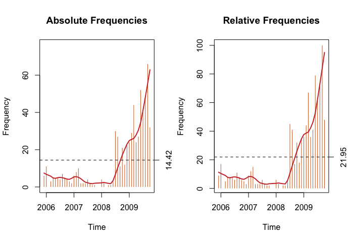

```r
par(mfrow = c(1, 2))
zeitPlot(merkel_3_freq, title = "Absolute Frequencies")
zeitPlot(merkel_3_freq, title = "Relative Frequencies", absolute = FALSE)
```

There are several parameters to customize the plot. To hide the trend line or the mean line we set the the parameters `trend` or `mean` to `FALSE`:

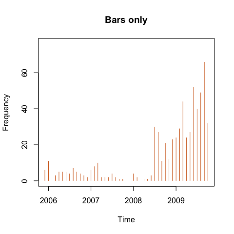

```r
zeitPlot(merkel_3_freq, title = "Bars only",
                 trend = FALSE, mean = FALSE)
```

Colors, line types, line widths and text size and orientation can be changed using optional graphical parameters:

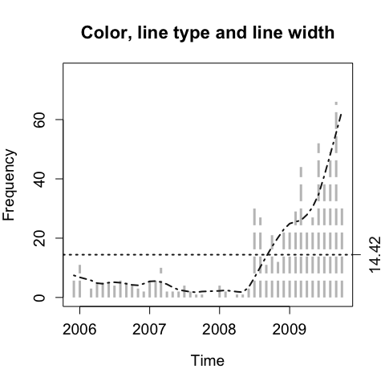

```r
zeitPlot(merkel_3_freq, title = "Color, line type and line width",
                 col.bar = "#C1C1C1", lty.bar = "longdash", lwd.bar = 3,
                 col.trend = "#181818", lty.trend = "dotdash", lwd.trend = 2,
                 col.mean = "#181818", lty.mean = "dotted", lwd.mean = 2,
                 cex = 1.2)
```